# Vehicle Detection Project

Software pipeline to identify vehicles in a video from a front-facing camera on a car.

The goals / steps of this project are the following:

- Perform a Histogram of Oriented Gradients (HOG) feature extraction on a labeled training set of images and train a classifier Linear SVM classifier
- Optionally, you can also apply a color transform and append binned color features, as well as histograms of color, to your HOG feature vector.
- Note: for those first two steps don't forget to normalize your features and randomize a selection for training and testing.
- Implement a sliding-window technique and use your trained classifier to search for vehicles in images.
- Run your pipeline on a video stream (start with the test_video.mp4 and later implement on full project_video.mp4) and create a heat map of recurring detections frame by frame to reject outliers and follow detected vehicles.
- Estimate a bounding box for vehicles detected.

### Import Libraries

```python
import numpy as np
import cv2
import matplotlib.pyplot as plt
import matplotlib.image as mpimg
import glob
import pickle
from skimage.feature import hog
from sklearn.preprocessing import StandardScaler
from sklearn.model_selection import train_test_split
from sklearn.svm import LinearSVC
from scipy.ndimage.measurements import label
%matplotlib inline
import os
from random import randint
import time
import imageio
imageio.plugins.ffmpeg.download()
from moviepy.editor import VideoFileClip
from IPython.display import HTML
```

### Define Constants

```python
PATH_TEST_IMAGES = './test_images/'
PATH_TRAINING_IMAGES = './data/'
IMAGE_DATA_PICKEL_FILE = 'images.p'
CLASSIFIER_DATA_PICKLE_FILE = 'data.p'

COLOR_SPACE      = 'YUV' # Can be RGB, HSV, LUV, HLS, YUV, YCrCb
ORIENT           = 15  # HOG orientations
PIX_PER_CELL     = 8 # HOG pixels per cell
CELL_PER_BLOCK   = 2 # HOG cells per block
HOG_CHANNEL      = "ALL" # Can be 0, 1, 2, or "ALL"
SPATIAL_SIZE     = (32, 32) # Spatial binning dimensions
HIST_BINS        = 32    # Number of histogram bins
SPATIAL_FEAT     = True # Spatial features on or off
HIST_FEAT        = True # Histogram features on or off
HOG_FEAT         = True # HOG features on or off
Y_START          = [400,400,410,420,430,430,440,400,400,500]
Y_STOP           = [500,500,500,555,555,555,555,555,555,555]
SCALE            = [1.0,1.3,1.4,1.6,1.8,2.0,1.9,1.3,2.2,3.0]
```

### Define Helper Functions

```python
# Helper functions

def Plot2Images(Image1, Image1Label, Image2, Image2Label):
    f, (ax1, ax2) = plt.subplots(1, 2, figsize=(6, 3))
    f.tight_layout()
    ax1.imshow(Image1)
    ax1.set_title(Image1Label, fontsize=20)
    ax2.imshow(Image2)
    ax2.set_title(Image2Label, fontsize=20)
    plt.subplots_adjust(left=0., right=1., top=1., bottom=0.)

def Plot3Images(image1, image2, image3):
    f, (ax1, ax2, ax3) = plt.subplots(1, 3, figsize=(24, 9))
    f.tight_layout()
    ax1.imshow(image1)
    ax2.imshow(image2)
    ax3.imshow(image3)
    plt.subplots_adjust(left=0., right=1, top=0.9, bottom=0.)

def draw_boxes(img, bboxes, color=(0, 0, 255), thick=6):
    # make a copy of the image
    img_draw = img.copy()
    # draw each bounding box on your image copy using cv2.rectangle()
    for bbox in bboxes:
        cv2.rectangle(img_draw, bbox[0], bbox[1], color, thick)
    # return the image copy with boxes drawn
    return img_draw
```

```python
def GetTestImages(path=PATH_TEST_IMAGES):
    filePaths = glob.glob(path+'test*.jpg')
    images = [cv2.cvtColor(cv2.imread(filePath), cv2.COLOR_BGR2RGB) for filePath in filePaths]
    return np.array(images)

def load_training_file_paths(base_path=PATH_TRAINING_IMAGES):
    # Collect Image files paths in a list
    # Collect Vehicle Image file paths
    GTI_Far = glob.glob(base_path + "vehicles/GTI_Far/*.png")
    GTI_Left =  glob.glob(base_path + "vehicles/GTI_left/*.png")
    GTI_Right =  glob.glob(base_path + "vehicles/GTI_right/*.png")
    GTI_MiddleClose =  glob.glob(base_path + "vehicles/GTI_MiddleClose/*.png")
    KITTI_Extracted =  glob.glob(base_path + "vehicles/KITTI_extracted/*.png")
    Vehicle_Paths = GTI_Far + GTI_Left + GTI_Right + GTI_MiddleClose + KITTI_Extracted
    # Collect Non-Vehicle Image file paths
    NonVehicles_GTI =  glob.glob(base_path + "non-vehicles/GTI/*.png")
    NonVehicles_Extras = glob.glob(base_path+"non-vehicles/Extras/*.png")
    NonVehicle_Paths = NonVehicles_GTI + NonVehicles_Extras

    return Vehicle_Paths, NonVehicle_Paths

def load_training_img_data(Vehicle_Paths, NonVehicle_Paths, Fpath=IMAGE_DATA_PICKEL_FILE):
    if os.path.isfile(Fpath):
        with open(IMAGE_DATA_PICKEL_FILE, mode='rb') as f:
            print('loading from pickle file...')
            images_pickle = pickle.load(f)
    else:
        # Load Vehicle Images
        VehicleImages = [mpimg.imread(filePath) for filePath in Vehicle_Paths]
        # Load Non-Vehicle Images
        NonVehicleImages = [mpimg.imread(filePath) for filePath in NonVehicle_Paths]
        images_pickle = {}
        images_pickle["Vehicle"] = np.array(VehicleImages)
        images_pickle["NonVehicle"] = np.array(NonVehicleImages)
        print('Saving to pickle file...')
        pickle.dump(images_pickle, open(IMAGE_DATA_PICKEL_FILE, "wb"))
    return images_pickle["Vehicle"], images_pickle["NonVehicle"]

def load_classifier_data(VehicleImages, NonVehicleImages,  Fpath=CLASSIFIER_DATA_PICKLE_FILE):
    if os.path.isfile(Fpath):
        with open(CLASSIFIER_DATA_PICKLE_FILE, mode='rb') as f:
            print('loading from pickle file...')
            data_pickle = pickle.load(f)
    else:
        # Extract Vehicle Features
        Vehicle_Features = extract_features(VehicleImages)
        # Create Vehicle Labels
        Vehicle_Labels = np.ones(len(Vehicle_Features))
        # Extract NonVehicle Features
        NonVehicle_Features = extract_features(NonVehicleImages)
        # Create NonVehicle Labels
        NonVehicle_Labels = np.zeros(len(NonVehicle_Features))

        # stack the features and labels
        X = np.vstack((Vehicle_Features, NonVehicle_Features)).astype(np.float64)
        # Fit a per-column scaler
        X_scaler = StandardScaler().fit(X)
        # Apply the scaler to X
        scaled_X= X_scaler.transform(X)

        # labels vector
        y = np.hstack((Vehicle_Labels, NonVehicle_Labels))

        # Shuffle data
        rand = np.random.randint(0, 100)
        X_train, X_test, y_train, y_test = train_test_split(scaled_X, y, test_size=0.2, random_state=rand)
        data_pickle = {}
        data_pickle["X_scaler"] = X_scaler
        data_pickle["X_train"] = np.array(X_train)
        data_pickle["X_test"] = np.array(X_test)
        data_pickle["y_train"] = np.array(y_train)
        data_pickle["y_test"] = np.array(y_test)
        print('Saving to pickle file...')
        pickle.dump(data_pickle, open(CLASSIFIER_DATA_PICKLE_FILE, "wb"))
    return data_pickle["X_scaler"], data_pickle["X_train"], data_pickle["X_test"], data_pickle["y_train"], data_pickle["y_test"]
```

```python
def color_hist(img, nbins=32):    #bins_range=(0, 256)
    # Compute the histogram of the color channels separately
    channel1_hist = np.histogram(img[:,:,0], bins=nbins)
    channel2_hist = np.histogram(img[:,:,1], bins=nbins)
    channel3_hist = np.histogram(img[:,:,2], bins=nbins)
    # Concatenate the histograms into a single feature vector
    hist_features = np.concatenate((channel1_hist[0], channel2_hist[0], channel3_hist[0]))
    # Return the individual histograms, bin_centers and feature vector
    return hist_features

def bin_spatial(img, size=(32, 32)):
    color1 = cv2.resize(img[:,:,0], size).ravel()
    color2 = cv2.resize(img[:,:,1], size).ravel()
    color3 = cv2.resize(img[:,:,2], size).ravel()
    return np.hstack((color1, color2, color3))

def getColorChannelsFromImage(img, colorSpace=COLOR_SPACE):
    if colorSpace == 'YUV':
        cvtImage = cv2.cvtColor(img, cv2.COLOR_RGB2YUV)
        ch1 = cvtImage[:,:,0]
        ch2 = cvtImage[:,:,1]
        ch3 = cvtImage[:,:,2]
    return ch1, ch2, ch3

def get_hog_features(img, orient=ORIENT, pix_per_cell=PIX_PER_CELL, cell_per_block=CELL_PER_BLOCK,
                        visualize=False, feature_vec=True):
    # Call with two outputs if vis==True
    if visualize == True:
        features, hog_image = hog(img, orientations=orient,
                                  pixels_per_cell=(pix_per_cell, pix_per_cell),
                                  cells_per_block=(cell_per_block, cell_per_block),
                                  transform_sqrt=False,
                                  #block_norm='L1',
                                  visualize=visualize, feature_vector=feature_vec)
        return features, hog_image
    # Otherwise call with one output
    else:
        features = hog(img, orientations=orient,
                       pixels_per_cell=(pix_per_cell, pix_per_cell),
                       cells_per_block=(cell_per_block, cell_per_block),
                       transform_sqrt=False,
                       #block_norm='L1',
                       visualize=visualize, feature_vector=feature_vec)
        return features

# a function to extract features from a list of images
def extract_features(images, color_space=COLOR_SPACE, spatial_size=SPATIAL_SIZE,
                        hist_bins=HIST_BINS, orient=ORIENT,
                        pix_per_cell=PIX_PER_CELL, cell_per_block=CELL_PER_BLOCK, hog_channel=HOG_CHANNEL,
                        spatial_feat=SPATIAL_FEAT, hist_feat=HIST_FEAT, hog_feat=HOG_FEAT):
    # Create a list to append feature vectors to
    features = []
    # Iterate through the list of images
    for image in images:
        image_features = []
        # apply color conversion if other than 'RGB'
        if color_space != 'RGB':
            if color_space == 'HSV':
                feature_image = cv2.cvtColor(image, cv2.COLOR_RGB2HSV)
            elif color_space == 'LUV':
                feature_image = cv2.cvtColor(image, cv2.COLOR_RGB2LUV)
            elif color_space == 'HLS':
                feature_image = cv2.cvtColor(image, cv2.COLOR_RGB2HLS)
            elif color_space == 'YUV':
                feature_image = cv2.cvtColor(image, cv2.COLOR_RGB2YUV)
            elif color_space == 'YCrCb':
                feature_image = cv2.cvtColor(image, cv2.COLOR_RGB2YCrCb)
        else:
            feature_image = np.copy(image)

        if spatial_feat == True:
            spatial_features = bin_spatial(feature_image, size=spatial_size)
            image_features.append(spatial_features)
        if hist_feat == True:
            # Apply color_hist()
            hist_features = color_hist(feature_image, nbins=hist_bins)
            image_features.append(hist_features)
        if hog_feat == True:
        # Call get_hog_features() with vis=False, feature_vec=True
            if hog_channel == 'ALL':
                hog_features = []
                for channel in range(feature_image.shape[2]):
                    hog_features.append(get_hog_features(feature_image[:,:,channel], orient, pix_per_cell, cell_per_block,
                                        visualize=False, feature_vec=True))
                hog_features = np.ravel(hog_features)
            else:
                hog_features = get_hog_features(feature_image[:,:,hog_channel], orient, pix_per_cell, cell_per_block,
                                        visualize=False, feature_vec=True)
            # Append the new feature vector to the features list
            image_features.append(hog_features)
        features.append(np.concatenate(image_features))
    # Return list of feature vectors
    return features

# a function to extract features from a list of images
def extract_old_features(imgs, color_space='RGB', spatial_size=(32, 32),
                        hist_bins=32, orient=9,
                        pix_per_cell=8, cell_per_block=2, hog_channel=0,
                        spatial_feat=True, hist_feat=True, hog_feat=True):
    # Create a list to append feature vectors to
    features = []
    # Iterate through the list of images
    for file in imgs:
        file_features = []
        # Read in each one by one
        image = mpimg.imread(file)
        # apply color conversion if other than 'RGB'
        if color_space != 'RGB':
            if color_space == 'HSV':
                feature_image = cv2.cvtColor(image, cv2.COLOR_RGB2HSV)
            elif color_space == 'LUV':
                feature_image = cv2.cvtColor(image, cv2.COLOR_RGB2LUV)
            elif color_space == 'HLS':
                feature_image = cv2.cvtColor(image, cv2.COLOR_RGB2HLS)
            elif color_space == 'YUV':
                feature_image = cv2.cvtColor(image, cv2.COLOR_RGB2YUV)
            elif color_space == 'YCrCb':
                feature_image = cv2.cvtColor(image, cv2.COLOR_RGB2YCrCb)
        else: feature_image = np.copy(image)

        if spatial_feat == True:
            spatial_features = bin_spatial(feature_image, size=spatial_size)
            file_features.append(spatial_features)
        if hist_feat == True:
            # Apply color_hist()
            hist_features = color_hist(feature_image, nbins=hist_bins)
            file_features.append(hist_features)
        if hog_feat == True:
        # Call get_hog_features() with vis=False, feature_vec=True
            if hog_channel == 'ALL':
                hog_features = []
                for channel in range(feature_image.shape[2]):
                    hog_features.append(get_old_hog_features(feature_image[:,:,channel],
                                        orient, pix_per_cell, cell_per_block,
                                        vis=False, feature_vec=True))
                hog_features = np.ravel(hog_features)
            else:
                hog_features = get_old_hog_features(feature_image[:,:,hog_channel], orient,
                            pix_per_cell, cell_per_block, vis=False, feature_vec=True)
            # Append the new feature vector to the features list
            file_features.append(hog_features)
        features.append(np.concatenate(file_features))
    # Return list of feature vectors
    return features

def get_old_hog_features(img, orient, pix_per_cell, cell_per_block,
                        vis=False, feature_vec=True):
    # Call with two outputs if vis==True
    if vis == True:
        features, hog_image = hog(img, orientations=orient,
                                  pixels_per_cell=(pix_per_cell, pix_per_cell),
                                  cells_per_block=(cell_per_block, cell_per_block),
                                  transform_sqrt=False,
                                  visualise=vis, feature_vector=feature_vec)
        return features, hog_image
    # Otherwise call with one output
    else:
        features = hog(img, orientations=orient,
                       pixels_per_cell=(pix_per_cell, pix_per_cell),
                       cells_per_block=(cell_per_block, cell_per_block),
                       transform_sqrt=False,
                       visualise=vis, feature_vector=feature_vec)
        return features

def convert_color(img, conv='RGB2YCrCb'):
    if conv == 'RGB2YCrCb':
        return cv2.cvtColor(img, cv2.COLOR_RGB2YCrCb)
    if conv == 'BGR2YCrCb':
        return cv2.cvtColor(img, cv2.COLOR_BGR2YCrCb)
    if conv == 'RGB2LUV':
        return cv2.cvtColor(img, cv2.COLOR_RGB2LUV)
    if conv == 'RGB2YUV':
        return cv2.cvtColor(img, cv2.COLOR_RGB2YUV)
```

```python
def add_heat(heatmap, bbox_list):
    # Iterate through list of bboxes
    for box in bbox_list:
        # Add += 1 for all pixels inside each bbox
        # Assuming each "box" takes the form ((x1, y1), (x2, y2))
        heatmap[box[0][1]:box[1][1], box[0][0]:box[1][0]] += 1

    # Return updated heatmap
    return heatmap# Iterate through list of bboxes

def apply_threshold(heatmap, threshold):
    # Zero out pixels below the threshold
    heatmap[heatmap <= threshold] = 0
    # Return thresholded map
    return heatmap

def draw_labeled_bboxes(img, labels):
    # Iterate through all detected cars
    for car_number in range(1, labels[1]+1):
        # Find pixels with each car_number label value
        nonzero = (labels[0] == car_number).nonzero()
        # Identify x and y values of those pixels
        nonzeroy = np.array(nonzero[0])
        nonzerox = np.array(nonzero[1])
        # Define a bounding box based on min/max x and y
        bbox = ((np.min(nonzerox), np.min(nonzeroy)), (np.max(nonzerox), np.max(nonzeroy)))
        # Draw the box on the image
        cv2.rectangle(img, bbox[0], bbox[1], (0,0,255), 6)
    # Return the image
    return img

def get_heatmap(bboxes, img):
    threshold = 1
    heat = np.zeros_like(img[:,:,0]).astype(np.float)
    heat = add_heat(heat, bboxes)
    heat = apply_threshold(heat, threshold)
    heatmap = np.clip(heat, 0, 255)
    return heatmap
```

### Load Test Images

```
Number of Images:  6
Image Dimensons:  (720, 1280, 3)
```

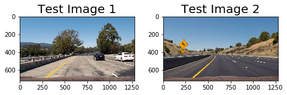

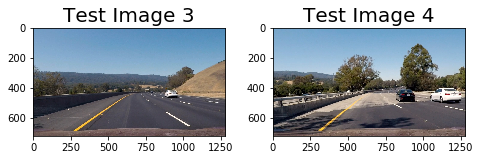

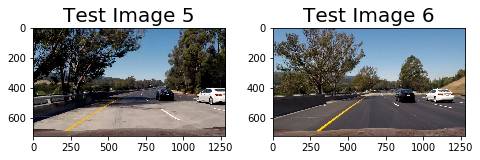

```python
test_images = GetTestImages()
print("Number of Images: ", test_images.shape[0])
print("Image Dimensons: ", test_images.shape[1:])
Plot2Images(test_images[0], 'Test Image 1', test_images[1], 'Test Image 2')
Plot2Images(test_images[2], 'Test Image 3', test_images[3], 'Test Image 4')
Plot2Images(test_images[4], 'Test Image 5', test_images[5], 'Test Image 6')
```

### Load Training Images

```python
# Extract filenames
Vehicle_Paths, NonVehicle_Paths = load_training_file_paths()
# Load Training Images
VehicleImages, NonVehicleImages = load_training_img_data(Vehicle_Paths, NonVehicle_Paths)
```

```
loading from pickle file...
```

```python
len(Vehicle_Paths), len(NonVehicle_Paths)
```

```
(8792, 8968)
```

```python
print('Total Vehcile Images: ', VehicleImages.shape[0])
print('Total NonVehicle Images', NonVehicleImages.shape[0])
print('Image Size: ', VehicleImages.shape[1:])
```

```
Total Vehcile Images:  8792
Total NonVehicle Images 8968
Image Size:  (64, 64, 3)
```

```
Sample Random Vehicle Data
```

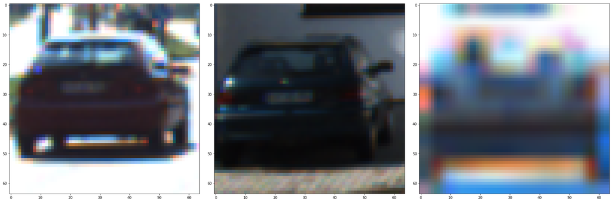

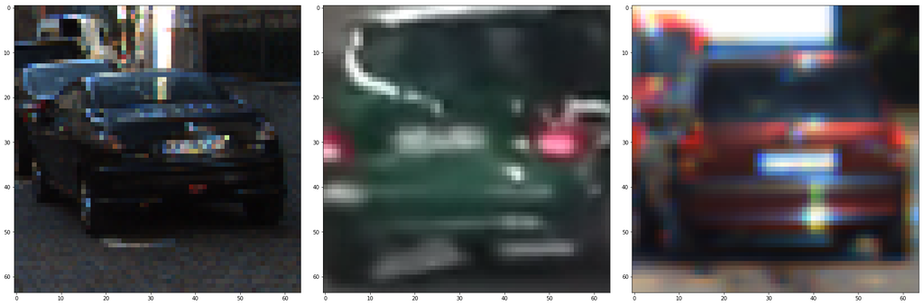

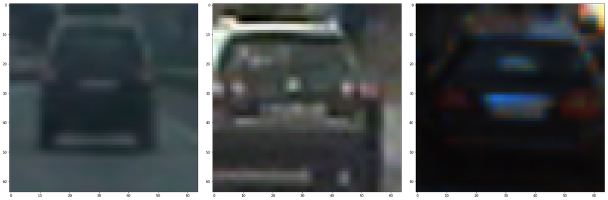

```python
print('Sample Random Vehicle Data')
for i in range(3):
    rand1 = randint(0, VehicleImages.shape[0])
    rand2 = randint(0, VehicleImages.shape[0])
    rand3 = randint(0, VehicleImages.shape[0])
    Plot3Images(VehicleImages[rand1], VehicleImages[rand2],VehicleImages[rand3])
```

```
Sample Random NonVehicle Data
```

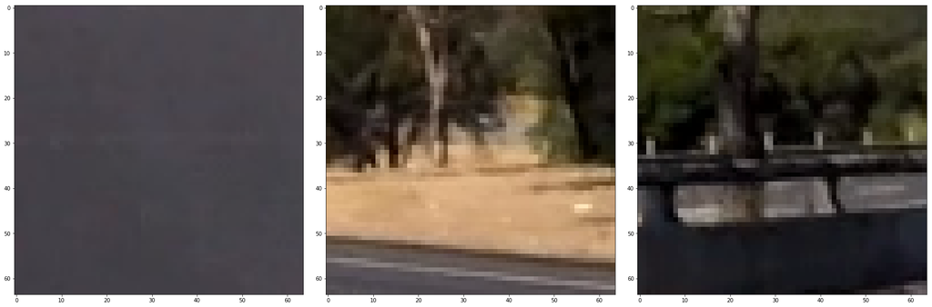

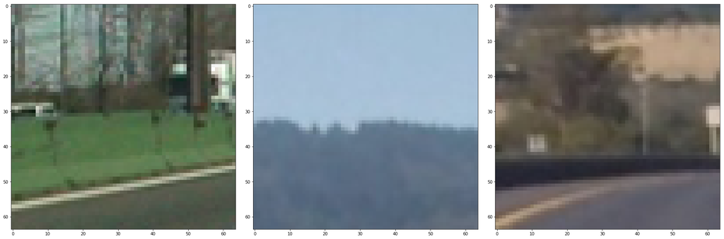

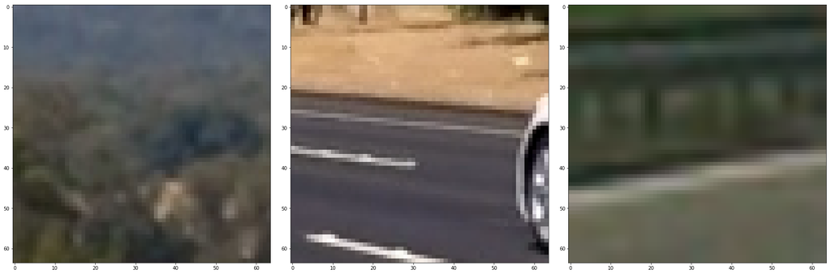

```python
print('Sample Random NonVehicle Data')
for i in range(3):
    rand1 = randint(0, NonVehicleImages.shape[0])
    rand2 = randint(0, NonVehicleImages.shape[0])
    rand3 = randint(0, NonVehicleImages.shape[0])
    Plot3Images(NonVehicleImages[rand1], NonVehicleImages[rand2],NonVehicleImages[rand3])
```

### Test Hog Feature Extractor

Vehicle Image

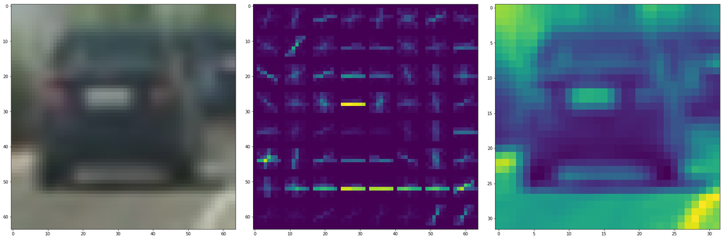

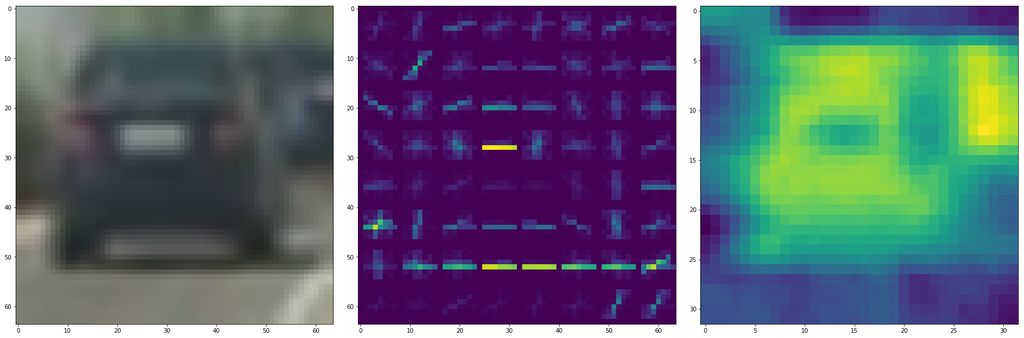

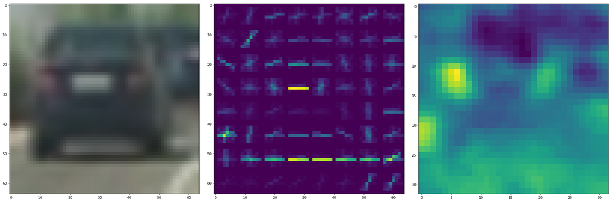

```python
# get random Vechicle Image
rand1 = 0#randint(0, VehicleImages.shape[0])
# Get individual color channels of converted images
vehicle_ch1, vehicle_ch2, vehicle_ch3 = getColorChannelsFromImage(VehicleImages[rand1])
# Extract hog features
vehicle_hog_feature, vehicle_hog_image = get_hog_features(vehicle_ch1, visualize=True)

vehicle_ch1_features = cv2.resize(vehicle_ch1, SPATIAL_SIZE)
vehicle_ch2_features = cv2.resize(vehicle_ch2, SPATIAL_SIZE)
vehicle_ch3_features = cv2.resize(vehicle_ch3, SPATIAL_SIZE)

Plot3Images(VehicleImages[rand1], vehicle_hog_image, vehicle_ch1_features)
Plot3Images(VehicleImages[rand1], vehicle_hog_image, vehicle_ch2_features)
Plot3Images(VehicleImages[rand1], vehicle_hog_image, vehicle_ch3_features)
```

Non-Vehicle Image

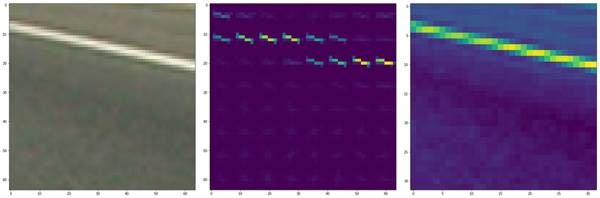

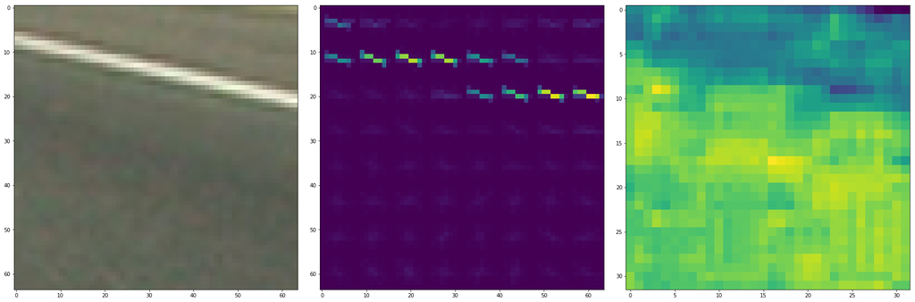

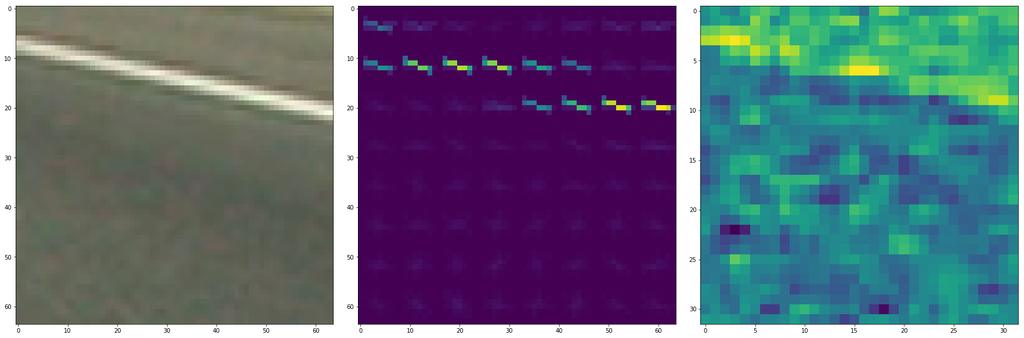

```python
# get random Non-Vechicle Image
rand2 = randint(0, NonVehicleImages.shape[0])
# Get individual color channels of converted images
vehicle_ch1, vehicle_ch2, vehicle_ch3 = getColorChannelsFromImage(NonVehicleImages[rand2])
# Extract hog features
vehicle_hog_feature, vehicle_hog_image = get_hog_features(vehicle_ch1, visualize=True)

vehicle_ch1_features = cv2.resize(vehicle_ch1, SPATIAL_SIZE)
vehicle_ch2_features = cv2.resize(vehicle_ch2, SPATIAL_SIZE)
vehicle_ch3_features = cv2.resize(vehicle_ch3, SPATIAL_SIZE)

Plot3Images(NonVehicleImages[rand2], vehicle_hog_image, vehicle_ch1_features)
Plot3Images(NonVehicleImages[rand2], vehicle_hog_image, vehicle_ch2_features)
Plot3Images(NonVehicleImages[rand2], vehicle_hog_image, vehicle_ch3_features)
```

### Create and Save Classifier Inputs

```python
X_scaler, X_train, X_test, y_train, y_test = load_classifier_data(VehicleImages, NonVehicleImages)
print('Total Training Features: ', X_train.shape[0])
print('Each Training Feature: ', X_train.shape[1:])
print('Total Training Labels: ', y_train.shape[0])
print('Total Testing Features: ', X_test.shape[0])
print('Each Testing Feature: ', X_test.shape[1:])
print('Total testing Labels: ', y_test.shape[0])
print('Labels : ', np.unique(y_train))
```

```
loading from pickle file...
Total Training Features:  14208
Each Training Feature:  (11988,)
Total Training Labels:  14208
Total Testing Features:  3552
Each Testing Feature:  (11988,)
Total testing Labels:  3552
Labels :  [0. 1.]
```

### SVM Classifier

```python
# Use a linear SVC
svc = LinearSVC()
# Check the training time for the SVC
t1=time.time()
svc.fit(X_train, y_train)
t2 = time.time()
print(round(t2-t1, 2), 'Seconds to train SVC...')
# Check the score of the SVC
print('Test Accuracy of SVC = ', round(svc.score(X_test, y_test), 4))
```

```
14.64 Seconds to train SVC...
Test Accuracy of SVC =  0.991
```

### Finding Cars

```python
def find_cars(img, svc, X_scaler, y_start, y_stop, scale, orient=ORIENT, pix_per_cell=PIX_PER_CELL, cell_per_block=CELL_PER_BLOCK, spatial_size=SPATIAL_SIZE, hist_bins=HIST_BINS):

    draw_img = np.copy(img)
    img = img.astype(np.float32)/255

    img_tosearch = img[y_start:y_stop,:,:]
    ctrans_tosearch = convert_color(img_tosearch, conv='RGB2YUV')
    if scale != 1:
        imshape = ctrans_tosearch.shape
        ctrans_tosearch = cv2.resize(ctrans_tosearch, (np.int(imshape[1]/scale), np.int(imshape[0]/scale)))

    ch1 = ctrans_tosearch[:,:,0]
    ch2 = ctrans_tosearch[:,:,1]
    ch3 = ctrans_tosearch[:,:,2]

    # Define blocks and steps as above
    nxblocks = (ch1.shape[1] // pix_per_cell) - cell_per_block + 1
    nyblocks = (ch1.shape[0] // pix_per_cell) - cell_per_block + 1
    nfeat_per_block = orient*cell_per_block**2

    # 64 was the orginal sampling rate, with 8 cells and 8 pix per cell
    window = 64
    nblocks_per_window = (window // pix_per_cell) - cell_per_block + 1
    #nblocks_per_window = (window // pix_per_cell)-1

    cells_per_step = 2  # Instead of overlap, define how many cells to step
    nxsteps = (nxblocks - nblocks_per_window) // cells_per_step
    nysteps = (nyblocks - nblocks_per_window) // cells_per_step

    # Compute individual channel HOG features for the entire image
    hog1 = get_hog_features(ch1, orient, pix_per_cell, cell_per_block, visualize=False, feature_vec=False)
    hog2 = get_hog_features(ch2, orient, pix_per_cell, cell_per_block, visualize=False, feature_vec=False)
    hog3 = get_hog_features(ch3, orient, pix_per_cell, cell_per_block, visualize=False, feature_vec=False)

    bboxes = []
    for xb in range(nxsteps):
        for yb in range(nysteps):
            ypos = yb*cells_per_step
            xpos = xb*cells_per_step
            # Extract HOG for this patch
            hog_feat1 = hog1[ypos:ypos+nblocks_per_window, xpos:xpos+nblocks_per_window].ravel()
            hog_feat2 = hog2[ypos:ypos+nblocks_per_window, xpos:xpos+nblocks_per_window].ravel()
            hog_feat3 = hog3[ypos:ypos+nblocks_per_window, xpos:xpos+nblocks_per_window].ravel()
            hog_features = np.hstack((hog_feat1, hog_feat2, hog_feat3))

            xleft = xpos*pix_per_cell
            ytop = ypos*pix_per_cell

            # Extract the image patch
            subimg = cv2.resize(ctrans_tosearch[ytop:ytop+window, xleft:xleft+window], (64,64))

            # Get color features
            spatial_features = bin_spatial(subimg, size=spatial_size)
            hist_features = color_hist(subimg, nbins=hist_bins)

            # Scale features and make a prediction
            test_stacked = np.hstack((spatial_features, hist_features, hog_features)).reshape(1, -1)
            test_features = X_scaler.transform(test_stacked)
            test_prediction = svc.predict(test_features)

            if test_prediction == 1:
                xbox_left = np.int(xleft*scale)
                ytop_draw = np.int(ytop*scale)
                win_draw = np.int(window*scale)
                cv2.rectangle(draw_img,(xbox_left, ytop_draw+y_start),(xbox_left+win_draw,ytop_draw+win_draw+y_start),(0,0,255),6)
                bboxes.append(((int(xbox_left), int(ytop_draw+y_start)),(int(xbox_left+win_draw),int(ytop_draw+win_draw+y_start))))

    return draw_img, bboxes
```

```python
def sliding_window(image, svc, X_scaler, y_start=Y_START, y_stop=Y_STOP, scale=SCALE, orient=ORIENT, pix_per_cell=PIX_PER_CELL, cell_per_block=CELL_PER_BLOCK, spatial_size=SPATIAL_SIZE, hist_bins=HIST_BINS):
    bboxes = []
    for i in range(len(y_start)):
        image, bbox = find_cars(image, svc, X_scaler, Y_START[i], Y_STOP[i], SCALE[i] , orient, pix_per_cell, cell_per_block, spatial_size, hist_bins)
        bboxes.extend(bbox)
    return image, bboxes
```

Verify find car pipeline on test images

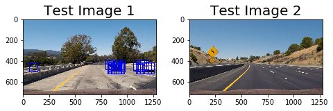

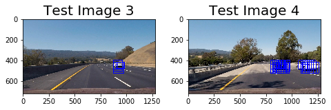

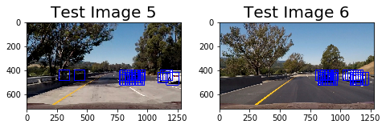

```python
output_images = []
bboxes = []

for idx, image in enumerate(test_images):
    output_image, bbox = sliding_window(image, svc, X_scaler=X_scaler)
    cv2.imwrite('./output_images/01_sliding_window_image_'+str(idx)+'.jpg', cv2.cvtColor(output_image, cv2.COLOR_BGR2RGB))
    output_images.append(output_image)
    bboxes.append(bbox)

Plot2Images(output_images[0], 'Test Image 1', output_images[1], 'Test Image 2')
Plot2Images(output_images[2], 'Test Image 3', output_images[3], 'Test Image 4')
Plot2Images(output_images[4], 'Test Image 5', output_images[5], 'Test Image 6')
```

Add Heat map to test images

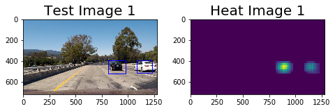

[figure not shown]

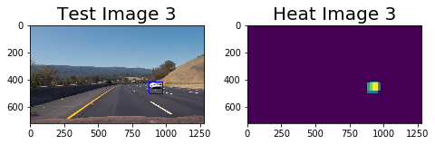

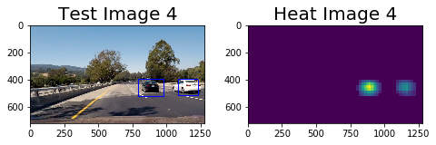

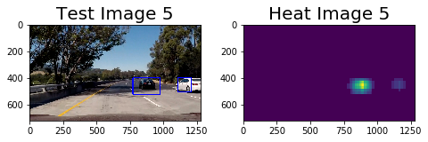

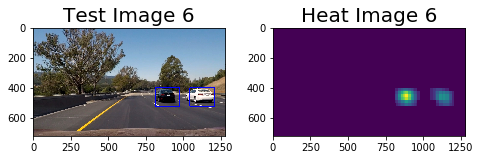

```python
heatmaps = []
corrected_imgs = []
for i in range(len(test_images)):
    heatmap = get_heatmap(bboxes[i], test_images[i])
    # Find final boxes from heatmap using label function
    corrected_img = draw_labeled_bboxes(np.copy(test_images[i]), label(heatmap))
    heatmaps.append(heatmap)
    corrected_imgs.append(corrected_img)

Plot2Images(corrected_imgs[0], 'Test Image 1', heatmaps[0], 'Heat Image 1')
Plot2Images(corrected_imgs[1], 'Test Image 2', heatmaps[1], 'Heat Image 2')
Plot2Images(corrected_imgs[2], 'Test Image 3', heatmaps[2], 'Heat Image 3')
Plot2Images(corrected_imgs[3], 'Test Image 4', heatmaps[3], 'Heat Image 4')
Plot2Images(corrected_imgs[4], 'Test Image 5', heatmaps[4], 'Heat Image 5')
Plot2Images(corrected_imgs[5], 'Test Image 6', heatmaps[5], 'Heat Image 6')
```

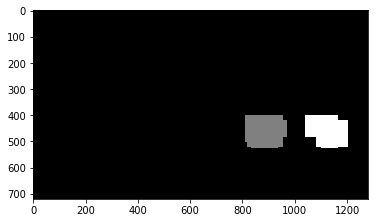

```python
plt.imshow(label(heatmap)[0], cmap='gray')
```

```python
from collections import deque
history = deque(maxlen = 25)

def pipeline(image, svc=svc, X_scaler=X_scaler, UseHistory=True):
    # Perform Sliding window and find cars
    output_image, bboxes = sliding_window(image, svc, X_scaler=X_scaler)



    # Find heatmap regions
    heatmap = get_heatmap(bboxes, output_image)

    if UseHistory:
        # Add to history
        history.append(heatmap)
        cumulative_heatmap = np.zeros_like(heatmap).astype(np.float)

        for heat in history:
            cumulative_heatmap = cumulative_heatmap + heat
        # Find final boxes from heatmap using label function
        corrected_img = draw_labeled_bboxes(np.copy(image), label(cumulative_heatmap))
    # Find final boxes from heatmap using label function
    #labels = label(heatmap)
    #draw_img = draw_labeled_bboxes(np.copy(image), labels)
    else:
        # Find final boxes from heatmap using label function
        corrected_img = draw_labeled_bboxes(np.copy(image), label(heatmap))
    return corrected_img
```

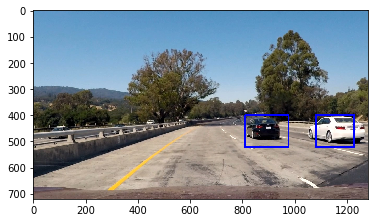

```python
history = deque(maxlen = 25)
test = pipeline(test_images[0], svc, X_scaler)
plt.imshow(test)
```

```python
pipeline_outputs = []

for idx, image in enumerate(test_images):
    pipeline_output = pipeline(image, svc, X_scaler=X_scaler, UseHistory=False)
    cv2.imwrite('./output_images/03_pipeline_output_'+str(idx)+'.jpg', cv2.cvtColor(pipeline_output, cv2.COLOR_BGR2RGB))
    pipeline_outputs.append(pipeline_output)
```

```python
#clip = VideoFileClip("test_video.mp4")
#video_clip = clip.fl_image(pipeline)
#%time video_clip.write_videofile('test_video_output.mp4', audio=False)
```

```python
#video_clip.close()
```

```python
clip = VideoFileClip("project_video.mp4")
video_clip = clip.fl_image(pipeline)
%time video_clip.write_videofile('project_video_output.mp4', audio=False)
```

```
[MoviePy] >>>> Building video project_video_output.mp4
[MoviePy] Writing video project_video_output.mp4
```

```
[MoviePy] Done.
[MoviePy] >>>> Video ready: project_video_output.mp4

Wall time: 43min 51s
```